# DCB3

*STATUS: Draft*

```python
import numpy as np
import sympy as sp
from IPython.display import HTML, IFrame
import ipywidgets as widgets
import matplotlib as mpl
from mpl_toolkits.mplot3d import Axes3D
import matplotlib.pyplot as plt
mpl.rcParams['legend.fontsize'] = 10
import pandas as pd
import itertools
from IPython.display import Image
import math



# function to print latex
def renderListToLatex(e):
    latex_rendering = []

    for i in range(len(e)):
        latex_rendering.append("$$" + sp.latex(e[i]) + "$$")

    return(HTML("".join(latex_rendering[0:])))
```

### Calculus and the affine geometry of the magical parabola (3)

**Aim**: To further explore the relationship between control points and related polynomials

**Observe**: Recall the dCB curve from the previous notebook, whose locus could be defined as the intesection of control points

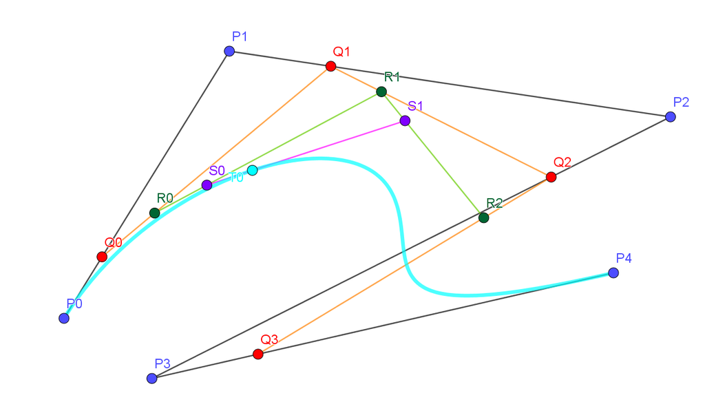

```python
Image("./Images/dCB1_1.PNG", width = 500)
```

**Let** $P0, P1 P2 \ldots$ is defined as an ongoing sequence of sequence of planar control points to arbitrary but finite length

```python
P0, P1, P2, P3, Q0, Q1, Q2, Q3, R0, R1, R2, R3, S0, S1, S2, S3, t, p01, p02, p11, p12, p21, p22 = sp.symbols('P0, P1, P2, P3, Q0, Q1, Q2, Q3, R0, R1, R2, R3, S0, S1, S2, S3, t, p01, p02, p11, p12, p21, p22 ')
```

**Observe**: Recall the relationship between these points and lines between these points from dCB1

```python
F1 = sp.Eq(Q0, (1 - t) * P0 + t * P1)
F2 = sp.Eq(Q1, (1 - t) * P1 + t * P2)
F3 = sp.Eq(Q2, (1 - t) * P2 + t * P3)

F4 = sp.Eq(R0, (1 - t) * Q0 + t * Q1)
F5 = sp.Eq(R1, (1 - t) * Q1 + t * Q2)
F6 = sp.Eq(R2, (1 - t) * Q2 + t * Q3)

F7 = sp.Eq(S0, (1 - t) * R0 + t * R1)
F8 = sp.Eq(S1, (1 - t) * R1 + t * R2)
F9 = sp.Eq(S2, (1 - t) * R2 + t * R3)

renderListToLatex([F1, F2, F3, F4, F5, F6, F7, F8, F9])
```

$$Q_{0} = P_{0} \left(1 - t\right) + P_{1} t$$$$Q_{1} = P_{1} \left(1 - t\right) + P_{2} t$$$$Q_{2} = P_{2} \left(1 - t\right) + P_{3} t$$$$R_{0} = Q_{0} \left(1 - t\right) + Q_{1} t$$$$R_{1} = Q_{1} \left(1 - t\right) + Q_{2} t$$$$R_{2} = Q_{2} \left(1 - t\right) + Q_{3} t$$$$S_{0} = R_{0} \left(1 - t\right) + R_{1} t$$$$S_{1} = R_{1} \left(1 - t\right) + R_{2} t$$$$S_{2} = R_{2} \left(1 - t\right) + R_{3} t$$

**Observe**: It is possible to view all of these expressions in terms of $P_0, P_1$ and $P_2$ using substitution.

**Let** $F10$ be a substution of $R_{0} = Q_{0} \left(1 - t\right) + Q_{1} t$ with $P0, P1$ and $P2$, grouped in terms of $t$

```python
F10 = F4.subs(Q0, P0 * (1 -t) + P1 * t).subs(Q1, P1 * (1 - t) + P2 * t)
F11 = sp.Eq(R0, F10.rhs.factor(t))
F11
```

$\displaystyle R_{0} = P_{0} + t^{2} \left(P_{0} - 2 P_{1} + P_{2}\right) + t \left(- 2 P_{0} + 2 P_{1}\right)$

**Observe**: To further explore this, it is possible to introduce some addititional vectors, created from the points $P0, P1$ and $P2$.

**Let** $F12, F13$ and $F14$ be vectors created with the control points $P_0, P_1$, and $P_2$, and use $v_0, v_1$ and $a_1$ to express these vectors.

```python
v0, v1, a1 = sp.symbols('v0, v1, a1')
F12 = sp.Eq(v0, P1 - P0)
F13 = sp.Eq(v1, P2 - P1)
F14 = sp.Eq(a1, P2 - 2 * P1 + P0)
renderListToLatex([F12, F13, F14])
```

$$v_{0} = - P_{0} + P_{1}$$$$v_{1} = - P_{1} + P_{2}$$$$a_{1} = P_{0} - 2 P_{1} + P_{2}$$

**Observe**: As vectors, $v_0, v_1$ and $a_1$ can be be intuited as traversing a single vector path.

**Observe**: As a consequence of the relationships of $F12, F13$ and $F14$, it follows that:

$$a_1 = v1 - v_0$$

and this implies that $a_1$ is defined as the subtraction between two vectors.

**Observe**: The choice of labels $v$ and $a$ is intended to provide an intuition of velocity and acceleration.

```python
F15 = sp.Eq(R0, P0 + 2 * t * v1 + t**2 * a1)
F15
```

$\displaystyle R_{0} = P_{0} + a_{1} t^{2} + 2 t v_{1}$

**Let** $F16$ be an alternative way of $F11$.

```python
F16 = sp.Eq(R0, P0 + t * ( P2 - P0) + (t**2 - t) * (P0 - 2 * P1 + P2))
F16
```

$\displaystyle R_{0} = P_{0} + t \left(- P_{0} + P_{2}\right) + \left(t^{2} - t\right) \left(P_{0} - 2 P_{1} + P_{2}\right)$

**Observe**: it can be verified that $F16$ and $F11$ are equivalent to each other.

```python
F16.expand() == F11.expand()
```

```
True
```

**Observe**: This suggests a new way of understanding how to move between points and rethink traditional notions of velocity and acceleration.

**Observe**: As a consequence of the relationships above, it also follows that $P2 - P0 \equiv v0 + v1$.

**Observe**: The above also shows that dCB curves have an algebraic foundation which goes hand in hand with thier affine construction.

**Aim**: Construct an Affine Plane using given assumptions

**Method**: Visualisation

**Observe**: dCB curves are created within the constraints of affine geometry.

**Observe**: Affine geometry makes the following assumptions:

1. A straight edge can be used to construct lines.
2. A straight edge can be used to construct lines that are parallel to other lines
3. Points can be constructed but they must be placed on a line
4. Lines can be constructed through points
5. Movement across lines and points is made using linear counting operations where addition, subtraction, multiplication and division are allowed, but limited to rational numbers.
6. All points and lines can be labelled arbitrarily

**Observe**: There is no notion of perpendicularity, distance, length, angle, quadrance or spread, which means that there are no metrical notions allowed

**Observe:** The following steps can be undertaken to create lines on an affine plane:

1. Construct some line, using a straight edge.
2. Construct any other line that is not parallel to the first line, using a straight edge
3. Construct a parallel line to each of the first two lines
4. Construct a line that passes through points that have been created by the constructed lines.
5. Constine to draw lines, creating more points and more lines.
6. This will create a grid of parallelograms

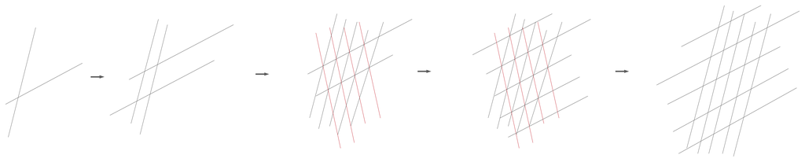

```python
Image("./Images/Lin1.png")
```

**Observe**: It is also possible to create subdivisions, using a similiar approach.

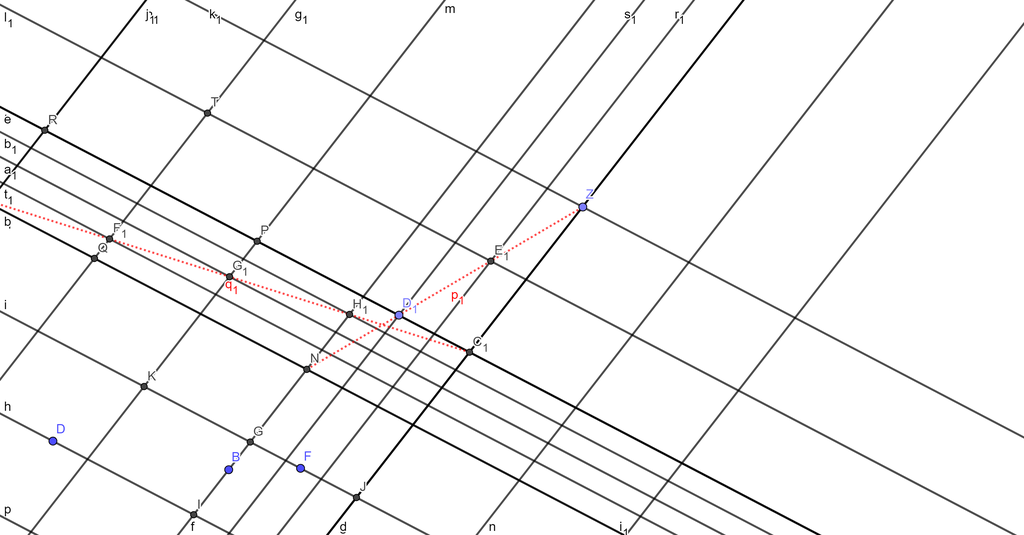

```python
Image("./Images/AffineGridSubdivision.png", width=500)
```

**Observe**: It is also possible to create polygons or abitrary complexity in relation to points that have been created.

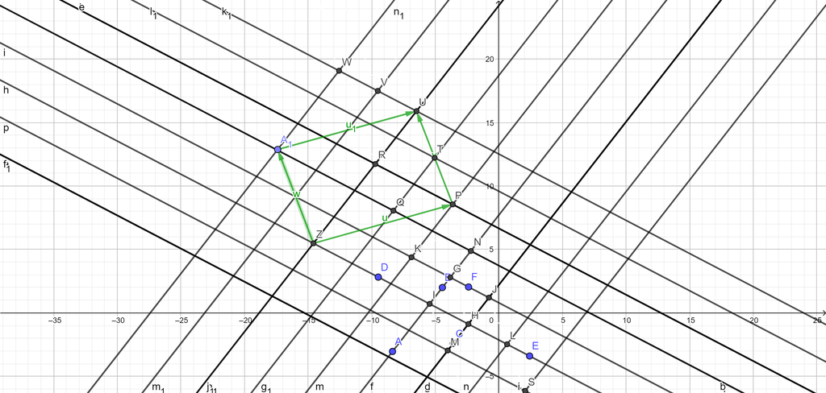

```python
Image("./Images/Affine GridQuadrilateral.png", width=500)
```

**Aim**: Use affine constructions to develop a deeper understanding about dCB curves.

**Observe**The value of $t$ has been set between 0 and 1 in the algebraic representation of dCB curves. However it is possible to the value of $t$ which will lead to more points on parabola

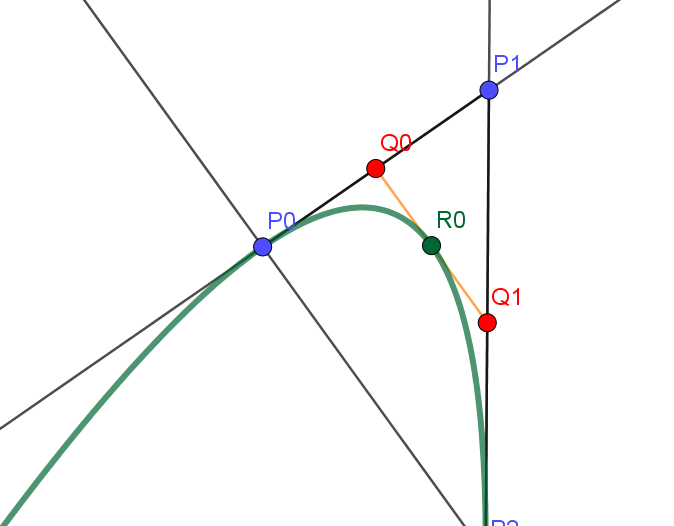

```python
Image("./Images/DCB3_1.PNG", width = 500)
```

**Observe**: There is a notion of direction for the above parabola, intuited as the direction through which the parabaola opens up. This is a vector, denoted as the Axis Direction for the parabola. Other attributes that are usually used to describe parabolas (such as focus, directrix, vertex) will not be used.

**Observe**: To obtain an axis direction through affine methods for this parabola (sketch below):

1. Construct a line incident to $P0$, parallel to the line indicident to $P1, P2$
2. Construct a line incident to $P2$, parallel to the line indicident to $P0, P1$
3. Label the intersection the two lines as $A$
4. Note that this constructs the paralleogram $P0, P1, P2, A$
5. Construct a line from $A$ to $P1$, noting that this line is the diagonal of parallelogram
6. Label the interection of the line from $P1$ to $A$ and the line from $P0$ to $P2$ as $B$

**Observe**: The point is the midpoint of the line from $P0$ to $P2$.

**Observe**: Recall the vector $a_1 = v_1 = v0$. In the context of below diagram, $a_1$ is vector from P1 to A. This is called the axis direction of the parabola.

**Definition**: The **Axis Direction** of a parabola, given by $a_1$ is the distinguised direction of the parabola vertex (Note there is no distinguished axis), which depends on the the control points.

**Observe**: The **Axis Direction** which can algebraically be described as $a_1$ is an important canonical oject with regard to curves within this space.

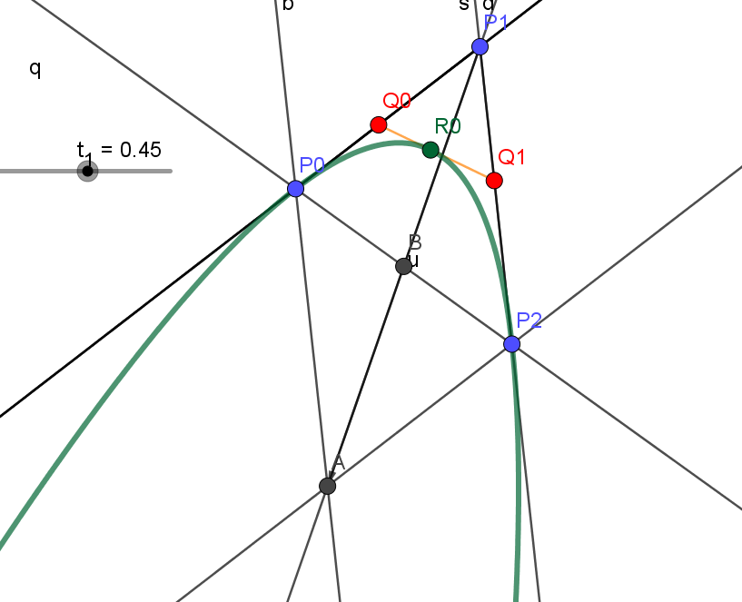

```python
Image("./Images/DCB3_2.PNG", width = 500)
```

**Aim**: Construct a tangent for the dCB curve above without knowledge of $Q0$ and $Q1$

**Observe**: Finding a tangent to a given curve is a fundamental problem in calculus.

**Observe**: To obtain the tangent to the curve as a affine construction (skectch below):

1. Construct a line that is incident to some point $R0$ on the parabola, and is parallel line to the line from $P1$ to $A$ (which is the axis direction of the parabola
2. Note the new intersection point incident to the line $P0$ to $P2$
3. Construct a line incidenct to the new intersection point and parallel to the line from $P1$ to $P2$
4. Construct a line incidenct to the new intersection point and parallel to the line from $P0$ to $A$
5. The newly created lines will go through points $Q0$ and $Q1$.

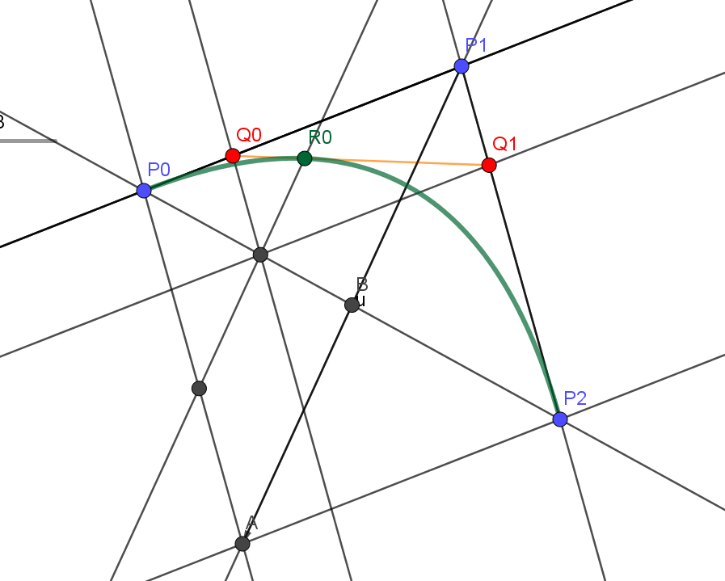

```python
Image("./Images/DCB_3_3.PNG", width = 500)
```

**Aim**: Demonstrate Achimedes' theorem of the area of an enclosed parabola.

**Observe** Area is intrinsically an affine notion in the context of the affine plane. It involves the idea of repeating a parallelogram, an idea which is powerful though rudimentary, showing that all area is relative to the affine plane.

**Observe**: This approach reformulates the idea of area as a way to subdivide and translate - cut and paste figures into another.

**Observe**: Consider the parallelogram below, $Q0,P1,Q1,D$ and note that, empirically, it has the same area as $P0, R0, P2$.

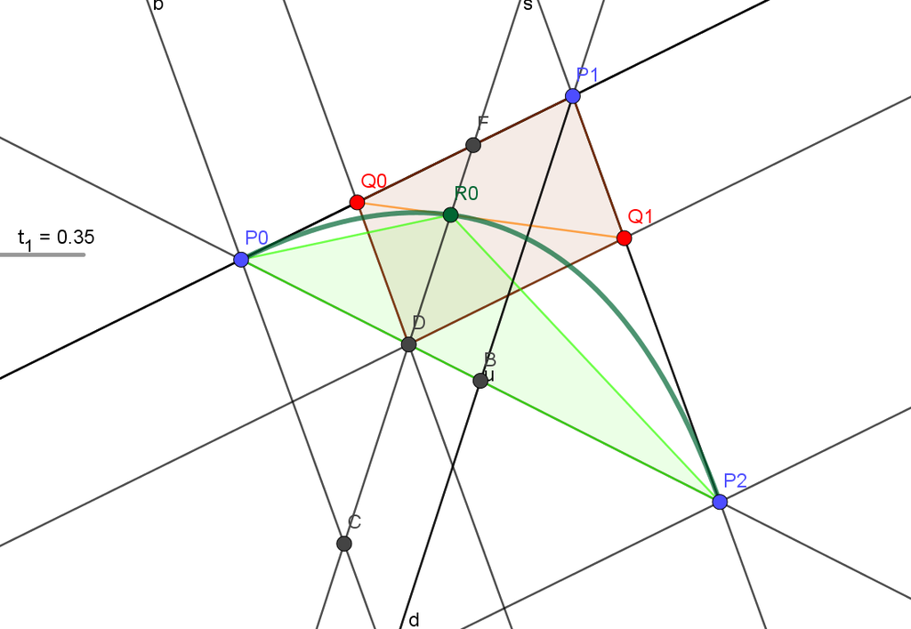

```python
Image("./Images/DCB3_4.PNG", width = 500)
```

**Observe**: As $t$ gets closer to .5, the area of the triangle above is maximised, which is also the point at which $t$ is incident to the axis direction vector.

**Observe**: This is related to Archimedes famous result, which states that the parabolic area (enclosed by curve and $P0$ and $P2$ is equivalent to $\frac{4}{3}$ of the triangle area.

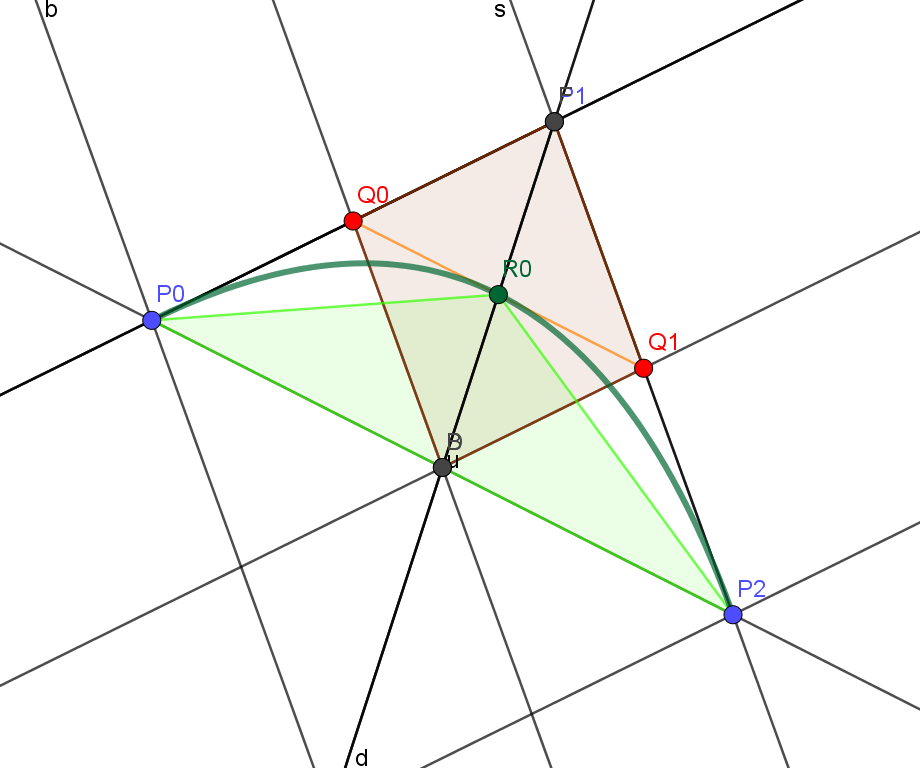

```python
Image("./Images/DCB3_5.PNG", width = 500)
```

**Observe** There are different ways to move between control points on the on the dCB curve, (i.e. from $P0$ to $P1$) and these are related to the algebraic formulations presented above.

**Todo** Explore how different applications of the algebraic formulas lead to different traversals across the vectors.